# MY472: Mid-Term Problem Set Solutions

LSE Candidate Number: 50799

Autumn Term 2024

## Exercise 1 (10 marks)

### Part 1. Clone Submission Repo and create directory structure

I have cloned my Submission Repo to a local directory on my computer. This is an “appropriate” location for permanently storing important files that is neatly organised. The ful path to this directory is `/Users/henriquerodrigues/Desktop/LSE/Y2/AT/Data_MY472/PS2`. I am storing inside my LSE folder, specifically inside a subfolder where I keep all the material for this course (`Data_MY472`). Inside that, I have created a folder for this problem set (`PS2`), where I clone the repository and keep other related files that I do not want to be pushed to Github.

Below is the code I used to clone the Repo:

```bash
### ex1.1

# setting path to directory
cd /Users/henriquerodrigues/Desktop/LSE/Y2/AT/Data_MY472/PS2

# cloning git repository to directory
git clone git@github.com:lse-my472/my472-at24-ps2-carol02r.git
```

In the local directory for my Submission Repo, I created a new folder for each of the exercises in this problem set and named them `ex1`, `ex2`, etc. Inside each of these folders, I made a copy of the file `MY472-AT24-ps2-answers.Rmd` and renamed it based on the exercise number using the following format: `MY472-AT24-ps2-ex*-answers.Rmd` (replacing the `*` with the actual exercise number).

For each exercise in this problem set, I will write up my answers in the relevant file for that exercise. I will also store my answers and any supporting files I create inside the relevant folder for that exercise.

### Part 2. Generate a screenshot

I produced a screenshot of the folder containing the local copy of your Submission Repo, where I show all the files and folders in a list format (including any hidden files). I also show the full pathway to the directory in the bottom of the screen.

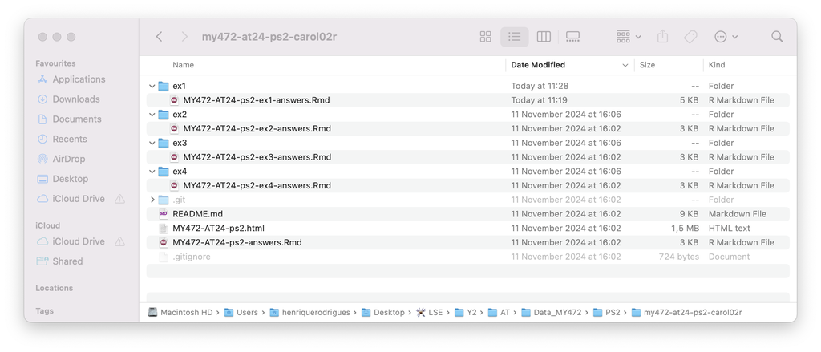

### Part 3. Figure out character encoding

I’ve downloaded `TextFile.txt`, which was not encoded using a UTF encoding, and saved it in the folder for this exercise. First, I figured out the file’s encoding by using the `guess_encoding()` function in tidyverse that helps you guess the encoding. This function suggests that the file is encoded using `Shift_JIS` with maximum confidence.

```r
### ex1.3

pathname <- '/Users/henriquerodrigues/Desktop/LSE/Y2/AT/Data_MY472/PS2/my472-at24-ps2-carol02r/ex1/TextFile.txt'

# using tidyverse's function to guess encoding
guess <- guess_encoding(pathname)

# printing result in a neater table
kable(guess, format = "html") %>%
  kable_styling("striped", full_width = FALSE, position = "left")
```

| encoding | confidence |
| --- | --- |
| Shift_JIS | 1.00 |
| windows-1252 | 0.23 |

Below I show what the text in this file looks like, after reading it in with encoding `Shift_JIS`:

```r
# trying out most likely encoding
text_data <- read_file(pathname, locale = locale(encoding="Shift_JIS"))

text_data
```

```
## [1] "石破内閣総理大臣発トランプ次期米国大統領宛祝辞\n\n１１月６日、石破茂内閣総理大臣から、ドナルド・トランプ次期米国大統領（The Honorable Donald J. Trump, President-elect of the United States of America）に対して、大統領選挙での勝利に対する祝意に加え、政権の最重要事項である日米同盟の更なる強化及び「自由で開かれたインド太平洋」の実現に向け、緊密に連携していきたい旨を記した祝辞を発出しました。"
```

The text is in a non-English language, so I used [Google Translate](https://translate.google.com/) to translate it to English. Below I show the complete translation:

[figure not shown]

This text is describing a short message sent from the Japanese Prime Minister to President-elect Donald Trump congratulating him for his victory in the presidential election.

Then, I save it as a new file with UTF-8 encoding in the `ex1` folder, with the file name `TextFileUTF.txt`.

```r
# saving file in utf-8
# since `readr` encodes as utf-8 by default, we can do the following:
write_file(text_data, "TextFileUTF.txt")
```

## Appendix: All code in this assignment

```r
# this chunk contains code that sets global options for the entire .Rmd.
# we use include=FALSE to suppress it from the top of the document, but it will still appear in the appendix.

knitr::opts_chunk$set(echo = FALSE) # actually set the global chunk options.
# we set echo=FALSE to suppress code such that it by default does not appear throughout the document.
# note: this is different from .Rmd default

# importing necessary packages
library(tidyverse)
library(knitr)
library(kableExtra)

### ex1.1

# setting path to directory
cd /Users/henriquerodrigues/Desktop/LSE/Y2/AT/Data_MY472/PS2

# cloning git repository to directory
git clone git@github.com:lse-my472/my472-at24-ps2-carol02r.git

### ex1.3

pathname <- '/Users/henriquerodrigues/Desktop/LSE/Y2/AT/Data_MY472/PS2/my472-at24-ps2-carol02r/ex1/TextFile.txt'

# using tidyverse's function to guess encoding
guess <- guess_encoding(pathname)

# printing result in a neater table
kable(guess, format = "html") %>%
  kable_styling("striped", full_width = FALSE, position = "left")

# trying out most likely encoding
text_data <- read_file(pathname, locale = locale(encoding="Shift_JIS"))

text_data

# saving file in utf-8
# since `readr` encodes as utf-8 by default, we can do the following:
write_file(text_data, "TextFileUTF.txt")

# this chunk generates the complete code appendix.
# eval=FALSE tells R not to run (``evaluate'') the code here (it was already run before).
```